# Mini-Project 2

Brennen Fagan

March 19, 2017

In this Mini-Project, we present the following equation and conditions, as well as attempt to recreate the figures shown in the original paper “Boltzmann and Fokker-Planck equations modelling opinion formation in the presence of strong leaders” by Bertram Düring, Peter Markowich, Jan-Frederik Pietschmann, and Marie-Therese Wolfram. We focus specifically on Figure 3.

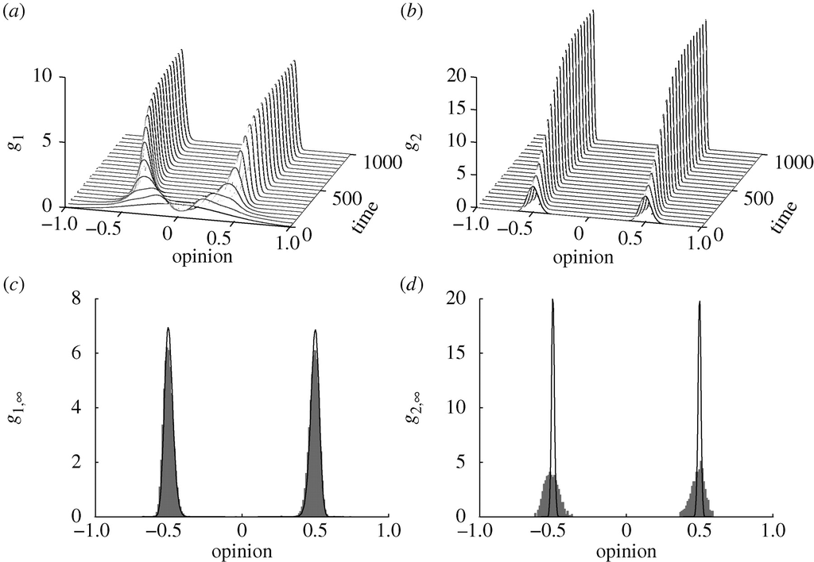

Figure 3 from “Boltzmann and Fokker-Planck equations modelling opinion formation in the presence of strong leaders”. In order, a) is the distribution of opinion followers, b) is the distribution of opinion leaders, c) and d) are the steady state distributions of the same. The shaded regions arose due in Monte-Carlo Simulation.

## The Equation

After modifications to approach steady state, the authors arrived at the system

$$w \in [-1,1]$$
$$\partial_{\tau} g_{1}(w,\tau)= \partial_{w}\left(\left(\frac{1}{\tau_{1,1}} \mathcal{K}_1 (w,\tau) + \frac{1}{2 \tau_{1,2}} \mathcal{K}_3(w,\tau)\right)g_1(w,\tau)\right) + \left(\frac{\lambda_{1,1} M_1}{2 \tau_{1,1}} + \frac{\lambda_{1,2} M_2}{4 \tau_{1,2}}\right) \partial^2_{ww} \left(D^2_1 (w) g_1 (w,\tau) \right)$$

$$\partial_{\tau} g_{2}(w,\tau)= \partial_{w}\left(\frac{1}{\tau_{2,2}} \mathcal{K}_2 (w,\tau) g_2(w,\tau)\right) + \frac{\lambda_{2,2} M_2}{2 \tau_{2,2}} \partial^2_{ww} \left(D^2_2 (w) g_2 (w,\tau) \right)$$

where $M_i = \int g_i dv$. This system is a Fokker-Planck system in which there are two simultaneously interacting populations. The first population, described by $g_1$, represents opinion followers, whose interactions influence each other. The second population, described by $g_2$, represents opinion leaders, whose interactions influence both each other and the followers. The above system uses the distribution functions $g_1, g_2$ over the space of possible opinions $w$ to track the evolution of the distributions of followers and leaders near the steady-state. Time is described by the variable $\tau$. The interactions between the populations are described by the functions $\mathcal{K}_i, D_1,$ and $D_2$. The first of these is the drift operator caused by interactions between the differing opinions of the population and is a function of the ability to reach compromise, itself described as the functions $P_i$ below.
$$\mathcal{K}_i(w,\tau) = \int_\mathcal{I}P_i(|w-v|)(w-v)g_i(v,\tau)dv \text{ for } i = 1,2$$
$$\mathcal{K}_3(w,\tau) = \int_\mathcal{I}P_3(|w-v|)(w-v)g_2(v,\tau)dv.$$
The latter two are the diffusion functions, representing the self interactions within the population.

The boundary conditions are given as:

$$(\frac{1}{\tau_{1,1}} \mathcal{K}_1 (w,\tau) + \frac{1}{2 \tau_{1,2}} \mathcal{K}_3(w,\tau))g_1(w,t) + (\frac{\lambda_{1,1} M_1}{2 \tau_{1,1}} + \frac{\lambda_{1,2} M_2}{4 \tau_{1,2}}) \partial_{w} (D^2_1 (w) g_1 (w,\tau) ) = 0 \text{ for } w = \pm 1$$
$$\frac{1}{\tau_{2,2}} \mathcal{K}_2 (w,\tau) g_2(w,t)+ \frac{\lambda_{2,2} M_2}{2 \tau_{2,2}} \partial_{w} (D^2_2 (w) g_2 (w,\tau) )= 0 \text{ for } w = \pm 1$$
$$D^2_1 (w) g_1 (w, \tau) = D^2_2 (w) g_2 (w, \tau) = 0 \text{ for } w = \pm 1.$$

These boundary conditions are derived originally by integration by parts and are chosen so as to allow no flux. As such, note that $w = \pm 1 \implies \partial_\tau g_1 = 0 = \partial_\tau g_2$ by the first two boundary conditions.

**GWD: I do not see why the time derivative would be zero at the boundary. I think quite to the contrary, the requirement that now probability flows outside the interval means that the boundary values of the density have to be allowed to be time-dependent. Now probably in your application it does not make much difference because the probability density will be close to zero at the boundary anyway.**

## Preparing for the problem

We gather the simplifying assumptions from the original paper, especially from section 4:

$$D_1(w) = D_2(w) = D(w):=(1-w^2)^\alpha, \text{ where } \alpha > \frac{1}{2}$$
$$P_i(|v-w|) = \mathbf{1}_{|v-w| \leq r_i} \text{ for } i \in \{1,2,3\}$$
$$\tau_{1,1} = \tau_{1,2} = \tau_{2,2} = 1$$
$$M_1 = 0.95, M_2 = 0.05$$
$$\lambda_{1,1} = \lambda_{1,2} = \lambda_{2,2} = \lambda := 5 \times 10^{-3}$$
$$\alpha = 2$$

Note specifically for the function $D$ that we have trivially satisfied our last boundary condition. We convert these to R code now.

```r
D <- function(w, alpha = 2){
  return ((1-w^2)^alpha)
}
D -> D1 -> D2
P <- function(v, w, r){
  return(ifelse(abs(v-w) <= r,1,0))
}
tau_1_1 = 1
tau_1_2 = 1
tau_2_2 = 1
M_1 = 0.95
M_2 = 0.05
M <- function(omega,g){
  N = length(g)-1
  #Trapezoidal Rule
  return(sum(omega*(g[1:N] + g[2:(N+1)])/2))
}
lambda = 5*10^-3
lambda -> lambda_1_1 -> lambda_1_2 -> lambda_2_2
```

Next, we consider the initial distributions of followers and leaders. These are given as follows.

$$g_1(w,0) = \frac{1}{\sqrt{2\pi}\sigma_1}\text{e}^{-(w-\sigma_1)^2/2}$$
$$\text{ where } \sigma_1 = 0.4$$
$$g_2(w,0) = \sum_{i=1}^n \frac{q_i}{\sqrt{2\pi}\sigma_i}\text{e}^{-(w-\sigma_i)^2/2}$$
$$\text{ where } \sum_{i=1}^n q_i = 1.$$

Less formally, we assume a static initial Gaussian for followers, while the initial distribution of opinion leaders is a linear combination of Gaussian that will change with the problem examined. In terms of R code, we represent these initial conditions as follows.

```r
gaussianEQN <- function(w, sigma, mu){
  return(((((2*pi)^.5)*sigma)^-1)*exp((-(w-mu)^2)/(2*sigma)))
}
theirGaussian <- function(w, sigma){
  return(((((2*pi)^.5)*sigma)^-1)*exp((-(w-sigma)^2)/(2)))
}
g1_w_0 <- function(w){
  return(gaussianEQN(w, 0.05, 0))
}
g2_w_0 <- function(w,qs,sigmas, mus){
  #We assume qs, mus, and sigmas are vectors of the same length
  Aggregate = 0*w
  for (i in 1:length(qs)){
    Aggregate = Aggregate + qs[i]*gaussianEQN(w,sigmas[i], mus[i])
  }
  return(Aggregate)
}
```

Notice that we choose, for example, $g_1(w,0) = \frac{1}{\sqrt{2\pi}\sigma_1}\text{e}^{-(w-w_1)^2/(2\sigma_1)}$. We suspect that the original paper has an error at this point. This is easily shown by the distributions of mass of the suggested curve versus the curves we have implemented.

**GWD: I am pleased you noticed their mistake. However your formula for the Gaussian is also not correct. In the exponent you should be dividing by the square of the standard deviation.**

```r
seq(-1,1, by = .01) -> x
plot(x, g1_w_0(x), xlab = "Opinion", ylab = "Mass of Followers", col = 1)
points(x, theirGaussian(x,0.4), col = 2)
```

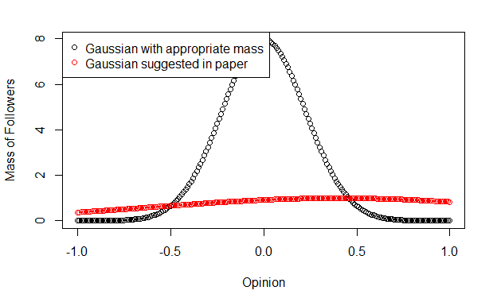

```r
legend("topleft", c("Gaussian with appropriate mass", "Gaussian suggested in paper"), col = c("black","red"), pch=c(1,1))
```

As our example demonstrates, the Gaussian suggested in the paper does not have mass that approaches zero near $-1$ and $1$, but instead remains quite high, in addition to being shifted so as to not be symmetric about $w=0$ as expected.

## Construction of the Algorithm

We will start handling the problem by deciding on a forward difference method. A quick remark; as noted in section 2.8, it is possible that the stability will depend not just on our step sizes, but also on the equation itself. We thus will need to be careful in our selection of our step sizes when using the algorithm. As such we will construct our grid. We take $N, Q \in \mathbb{N}$ and take $\omega = \frac{1-(-1)}{N}, \iota = \frac{T}{Q}$, where $T$ is the total time that the system is run for. We thus will define our grid points as $x_k = -1+\omega k$, $t_j = \iota j$ for $k = 0,\ldots,N, j = 0,\ldots, Q$. As such, we will write our approximations to $g_i(x_k, t_j)$ as $\gamma_{i,k,j}$.

Now we can construct a strategy to start handling portions of the problem at hand. We start by attempting to handle the evaluation of the drift operators. We reproduce them here for reader convenience.

$$\mathcal{K}_i = \int_\mathcal{I}P_i(|w-v|)(w-v)g_i(v,\tau)dv \text{ for } i = 1,2$$
$$\mathcal{K}_3 = \int_\mathcal{I}P_3(|w-v|)(w-v)g_2(v,\tau)dv.$$

Since we are working with a forward difference method, we will evaluate these for the previous time step’s $g_i$ using a naive trapezoidal method for approximation of the integral.

```r
K <- function(w,P,g,xgrid){
  #Naive Trapezoidal
  N = length(g)
  return(
    (2/N)*sum(
          ((w-xgrid[1:(N-1)])*(P(xgrid[1:(N-1)],w))*g[1:(N-1)])
          +((w-xgrid[2:(N)])*(P(xgrid[2:(N)],w))*g[2:(N)])
      )/2
    )
}
```

Clearly, $\partial_\tau g_i$ can be approximated by the forward difference step as usual.
$$\partial_t g_i(x_k, t_j) \approx \frac{g_i(x_k, t_j+\iota)-g_i(x_k, t_j)}{\iota} \implies \frac{\gamma_{i,k,j+1}-\gamma_{i,k,j}}{\iota}$$

Next, we shall handle the term $\partial_{w}(\frac{1}{\tau_{2,2}} \mathcal{K}_2 (w,\tau) g_2(w,t))$. Then we will extend the treatment given here to cover the term $\partial_{w}((\frac{1}{\tau_{1,1}} \mathcal{K}_1 (w,\tau) + \frac{1}{2 \tau_{1,2}} \mathcal{K}_3(w,\tau))g_1(w,t))$. Given that $\tau_{2,2}$ is constant, we need only consider the functions.

$$\begin{align}
\partial_{w}(\frac{1}{\tau_{2,2}} \mathcal{K}_2 (w,\tau) g_2(w,t)) &= \frac{1}{\tau_{2,2}}\partial_{w}( \mathcal{K}_2 (w,\tau) g_2(w,t))\\
&=\frac{1}{\tau_{2,2}}( \partial_{w}(\mathcal{K}_2 (w,\tau)) g_2(w,t))+\mathcal{K}_2 (w,\tau) \partial_{w}(g_2(w,t)))\\
&\implies \frac{1}{\tau_{2,2}}( \frac{\mathcal{K}_2(x_k+\omega,t_j)-\mathcal{K}_2(x_k,t_j)}{\omega}\gamma_{2,k,j} + \mathcal{K}_2(x_k,t_j)\frac{\gamma_{2,k+1,j}-\gamma_{2,k,j}}{\omega})\\
&=\frac{1}{\omega \tau_{2,2}}( \mathcal{K}_2(x_k+\omega,t_j)\gamma_{2,k,j}+ \mathcal{K}_2(x_k,t_j)\gamma_{2,k+1,j} - 2 \mathcal{K}_2(x_k,t_j)\gamma_{2,k,j})
\end{align}$$
GWD: I am surprised that you are using this rather complicated scheme with truncation error of $O(\omega)$. Why not simply use the central difference formula
$$\partial_{w}( \mathcal{K}_2 (w,\tau) g_2(w,t))=\frac{\mathcal{K}_2(x_k+\omega,t_j)\gamma_{2,k+1,j}-\mathcal{K}_2(x_k-\omega,t_j)\gamma_{2,k-1,j}}{2\omega}$$
which has truncation error of $O(\omega^2)$?

Our extension behaves similarly.

$$\begin{align}
\partial_{w}((\frac{1}{\tau_{1,1}} \mathcal{K}_1 (w,\tau) + \frac{1}{2 \tau_{1,2}} \mathcal{K}_3(w,\tau))g_1(w,t))
&=
\partial_{w}(\frac{1}{\tau_{1,1}} \mathcal{K}_1 (w,\tau)g_1(w,t)) + \partial_{w}(\frac{1}{2 \tau_{1,2}} \mathcal{K}_3(w,\tau)g_1(w,t)) \\
\implies& \frac{1}{\omega \tau_{1,1}}( \mathcal{K}_1(x_k+\omega,t_j)\gamma_{1,k,j}+ \mathcal{K}_1(x_k,t_j)\gamma_{1,k+1,j} - 2 \mathcal{K}_1(x_k,t_j)\gamma_{1,k,j}) \\
&+ \frac{1}{2 \omega \tau_{1,2}}( \mathcal{K}_3(x_k+\omega,t_j)\gamma_{1,k,j}+ \mathcal{K}_3(x_k,t_j)\gamma_{1,k+1,j} - 2 \mathcal{K}_3(x_k,t_j)\gamma_{1,k,j})
\end{align}$$

Finally, we consider the term $\partial^2_{ww} (D^2_i (w) g_i (w,\tau) )$ via central difference formula. Recall that $D_i(w) = (1-w^2)^2$.

$$\begin{align}
\partial^2_{ww} (D^2_i (w) g_i (w,\tau) ) &= \partial^2_{ww}(((1-w^2)^2)^2 g_i (w,\tau))\\
&= (1-w^2)^2 (48w^2 g_i(w, \tau) - 8 (1-w^2) g(w, \tau) - 16w(1-w^2)\partial_w g_i(w,\tau)+(1-w^2)\partial^2_w g(w,\tau))\\
\implies& (1-x_k^2)^2 (8(-1+7x_k^2) \gamma_{i,k,j} - 16x_k(1-x_k^2)\frac{\gamma_{i,k+1,j}-\gamma_{i,k,j}}{\omega}+(1-x_k^2)^2\frac{\gamma_{i,k+1,j}-2\gamma_{i,k,j}+\gamma_{i,k-1,j}}{\omega^2})
\end{align}$$
**Again, why so complicated? Why not simply use central difference?**

## Bringing the pieces together

We now can construct the algorithm in R code. We first present the unified system of equations for the next time step.

$$\begin{align}
\text{for } k = 1,\ldots, N-1\\
\gamma_{1,k,j+1}&=\gamma_{1,k,j}\\
&+\iota(\frac{1}{\omega \tau_{1,1}}( \mathcal{K}_1(x_k+\omega,t_j)\gamma_{1,k,j}+ \mathcal{K}_1(x_k,t_j)\gamma_{1,k+1,j} - 2 \mathcal{K}_1(x_k,t_j)\gamma_{1,k,j}) \\
&+ \frac{1}{2 \omega \tau_{1,2}}( \mathcal{K}_3(x_k+\omega,t_j)\gamma_{1,k,j}+ \mathcal{K}_3(x_k,t_j)\gamma_{1,k+1,j} - 2 \mathcal{K}_3(x_k,t_j)\gamma_{1,k,j}) \\
&+(\frac{\lambda_{1,1} M_1}{2 \tau_{1,1}} + \frac{\lambda_{1,2} M_2}{4 \tau_{1,2}})
(1-x_k^2)^2 (8(-1+7x_k^2) \gamma_{1,k,j} - 16x_k(1-x_k^2)\frac{\gamma_{1,k+1,j}-\gamma_{1,k,j}}{\omega}+(1-x_k^2)^2\frac{\gamma_{1,k+1,j}-2\gamma_{1,k,j}+\gamma_{1,k-1,j}}{\omega^2})
) \\
\\
\gamma_{2,k,j+1}&=\gamma_{2,k,j}\\
&+\iota(\frac{1}{\omega \tau_{2,2}}( \mathcal{K}_2(x_k+\omega,t_j)\gamma_{2,k,j}+ \mathcal{K}_2(x_k,t_j)\gamma_{2,k+1,j} - 2 \mathcal{K}_2(x_k,t_j)\gamma_{2,k,j})\\
&+\frac{\lambda_{2,2} M_2}{2 \tau_{2,2}}
(1-x_k^2)^2 (8(-1+7x_k^2) \gamma_{2,k,j} - 16x_k(1-x_k^2)\frac{\gamma_{2,k+1,j}-\gamma_{2,k,j}}{\omega}+(1-x_k^2)^2\frac{\gamma_{2,k+1,j}-2\gamma_{2,k,j}+\gamma_{2,k-1,j}}{\omega^2})
) \\
\\
\text{for } k = 0 \text{ or } k = N\\
\implies x_k = \pm 1\\
\gamma_{1,k,j+1} &= \gamma_{1,k,j}\\
\gamma_{2,k,j+1} &= \gamma_{2,k,j}
\end{align}$$

```r
Opinions <- function(gamma_1_x_0 = function(x) 0*x,
                     gamma_2_x_0 = function(x) 0*x,
                     T = 10, N = 200, Q = T*100000,
                     r1 = 0.5, r2 = 0.5, r3 = 0.5
                     ){
  #Define the Grid:
  #Space
  omega = (1-(-1))/N
  x = -1+omega*(0:N)

  #Time
  iota = T/Q
  t = 0+iota*(0:Q)

  #Define Remaining functions
  K1 <- function(w, g1){
    return(K(w,function(v,w) P(v,w,r1), g1, x))
  }

  K2 <- function(w, g2){
    return(K(w,function(v,w) P(v,w,r2), g2, x))
  }

  K3 <- function(w, g2){
    return(K(w,function(v,w) P(v,w,r3), g2, x))
  }

  #Setup Solution Matrices
  gamma_1 = matrix(0, N+1, Q+1)
  gamma_2 = matrix(0, N+1, Q+1)

  #Initial Conditions
  gamma_1[,1] = gamma_1_x_0(x)
  gamma_2[,1] = gamma_2_x_0(x)

  #Proceed point by point
  for(j in 1:Q){
    gamma_1[1, j+1] = gamma_1[1, j]
    gamma_2[1, j+1] = gamma_2[1, j]
    for(k in 2:N){
      #Perform the forward difference on the first equation
      aggregate_1 = 0
      aggregate_1 = aggregate_1 +
                    1/(tau_1_1*omega)*(
                    K1(x[k+1],gamma_1[,j])*gamma_1[k,j]
                    +K1(x[k],gamma_1[,j])*gamma_1[k+1,j]
                    -2*K1(x[k],gamma_1[,j])*gamma_1[k,j]
                    )
      aggregate_1 = aggregate_1 +
                    1/(2*tau_1_2*omega)*(
                    K3(x[k+1],gamma_1[,j])*gamma_1[k,j]
                    +K3(x[k],gamma_1[,j])*gamma_1[k+1,j]
                    -2*K3(x[k],gamma_1[,j])*gamma_1[k,j]
                    )
      aggregate_1 = aggregate_1 +
                    (lambda_1_1*M_1/(2*tau_1_1)+lambda_1_2*M_2/(4*tau_1_2))*((1-x[k]^2)^2)*
                    (8*(-1+7*x[k]^2)*gamma_1[k,j]-
                    16*x[k]*(1-x[k]^2)*(gamma_1[k+1,j]-gamma_1[k,j])/omega+
                    (x[k]^2-1)^2*(gamma_1[k+1,j]-2*gamma_1[k,j]+gamma_1[k-1,j])/(omega^2))
      gamma_1[k,j+1] = gamma_1[k,j]+iota*aggregate_1
      if(is.nan(gamma_1[k,j+1])){
        cat("Encountered NaN at location [1,",k,",", j+1,"]")
        return(list(x=x, t=t[1:j], g1 = gamma_1[,(1:j)], g2 = gamma_2[,(1:j)]))
      }
      if(gamma_1[k,j+1]<0){
        cat("Encountered negative at location [1,",k,",",j+1,"]")
        return(list(x=x, t=t[1:j], g1 = gamma_1[,(1:j)], g2 = gamma_2[,(1:j)]))
      }

      #Perform the forward difference on the second equation
      aggregate_2 = 0
      aggregate_2 = aggregate_2 +
                    1/(tau_2_2*omega)*(
                    K2(x[k+1],gamma_2[,j])*gamma_2[k,j]
                    +K2(x[k],gamma_2[,j])*gamma_2[k+1,j]
                    -2*K2(x[k],gamma_2[,j])*gamma_2[k,j]
                    )
      aggregate_2 = aggregate_2 +
                    lambda_2_2*M_2/(2*tau_2_2)*((1-x[k]^2)^2)*
                    (8*(-1+7*x[k]^2)*gamma_2[k,j]-
                    16*x[k]*(1-x[k]^2)*(gamma_2[k+1,j]-gamma_2[k,j])/omega+
                    (x[k]^2-1)^2*(gamma_2[k+1,j]-2*gamma_2[k,j]+gamma_2[k-1,j])/(omega^2))
      gamma_2[k,j+1] = gamma_2[k,j]+iota*aggregate_2
      if(is.nan(gamma_2[k,j+1])){
        cat("Encountered NaN at location [2,",k,",", j+1,"]")
        return(list(x=x, t=t[1:j], g1 = gamma_1[,(1:j)], g2 = gamma_2[,(1:j)]))
      }
      if(gamma_2[k,j+1]<0){
        cat("Encountered negative at location [2,",k,",",j+1,"]")
        return(list(x=x, t=t[1:j], g1 = gamma_1[,(1:j)], g2 = gamma_2[,(1:j)]))
      }
    }
    gamma_1[N+1, j+1] = gamma_1[N+1, j]
    gamma_2[N+1, j+1] = gamma_2[N+1, j]
  }
  return(list(x=x, t=t, g1 = gamma_1, g2 = gamma_2))
}
```

**GWD: It seems you are using D instead of D^2 in the above code.**

**GWD: One important remark about your code: when using a vector-oriented language (like for example R, python with numpy, matlab), you should do calculations with entire vectors rather than looping through the components of the vector and doing the calculation separately for each component. That is both more concise and much faster. Below is an example of code for the forward-difference method that looks much simpler and runs much faster and produces results similar to those in the paper. I simply adapted the code from Lab 11 a bit. I also use a clever way to evaluate the convolution integrals using Fourier transforms (look up “convolution theorem” in wikipedia).**

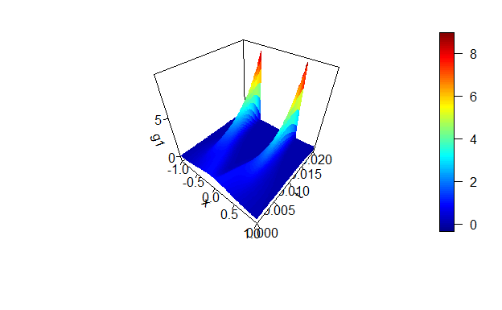

```r
K <- function(x, g, r) {
    Re(fft(fft(P(x, 0, r)*x)*fft(g), inverse = TRUE))*2/length(x)
}
w_1 <- -0.5
w_2 <- 0.5
sigma_1 <- sigma_2 <- 0.05
q_1 <- q_2 <- 0.5
g1_0 <- function(x) {
    exp(-(x/0.4)^2/2)/(sqrt(2*pi)*0.4)
}
g2_0 <- function(x) {
    q_1*exp(-((x-w_1)/sigma_1)^2/2)/(sqrt(2*pi)*sigma_1)+
         q_2* exp(-((x-w_2)/sigma_2)^2/2)/(sqrt(2*pi)*sigma_2)
}
alpha <-2
explicit <- function(g1_0=function(x) 0*x, g2_0=function(x) 0*x,
                     N=400, T=10, M=10000,
                     r1 = 0.5, r2 = 0.5, r3 = 0.5) {
    h <- 2/N
    x <- -1+(0:N)*h

    tau <- T/M
    M1 <- 100
    M2 <- round(M/M1)
    t <- (0:M1)*M2*tau

    d1 <- D1(x, alpha)^2
    d2 <- D2(x, alpha)^2

    w1 <- matrix(0, nrow=N+1, ncol=M1+1)
    w2 <- matrix(0, nrow=N+1, ncol=M1+1)

    gn1 <- g1_0(x)
    gn2 <- g2_0(x)
    w1[, 1] <- gn1
    w2[, 1] <- gn2

    for (j in 1:M1) {
        for (j2 in 1:M2) {

            g1 <- gn1
            g2 <- gn2

            a11 <- (K(x, g1, r1)/tau_1_1+K(x, g2, r3)/(2*tau_1_2))*g1
            a11p <- c(a11[2:(N+1)], a11[N])
            a11m <- c(a11[2], a11[1:N])
            a12 <- (lambda_1_1*M_1/(2*tau_1_1)+lambda_1_2*M_2/(4*tau_1_2))*d1*g1
            a12p <- c(a12[2:(N+1)], a12[N])
            a12m <- c(a12[2], a12[1:N])

            a21 <- K(x, g2, r2)/tau_2_2*g2
            a21p <- c(a21[2:(N+1)], a21[N])
            a21m <- c(a21[2], a21[1:N])
            a22 <- lambda_2_2*M_2/(2*tau_2_2)*d2*g2
            a22p <- c(a22[2:(N+1)], a22[N])
            a22m <- c(a22[2], a22[1:N])

            gn1 <- g1 + tau * (
                1/(2*h) * (a11p - a11m) + 1/h^2 * (a12p - 2*a12 + a12m)
            )

            gn2 <- g2 + tau * (
                1/(2*h) * (a21p - a21m) + 1/h^2 * (a22p - 2*a22 + a22m)
            )
        }
        w1[, j+1] <- gn1
        w2[, j+1] <- gn2
    }
    list(x=x, t=t, g1=w1, g2=w2)
}
sol <- explicit(g1_0, g2_0, N=200, T=0.02, M=1000)
persp3D(sol$x, sol$t, sol$g1,
        xlab="x", ylab="t", zlab="g1",
        ticktype="detailed", nticks=4)
```

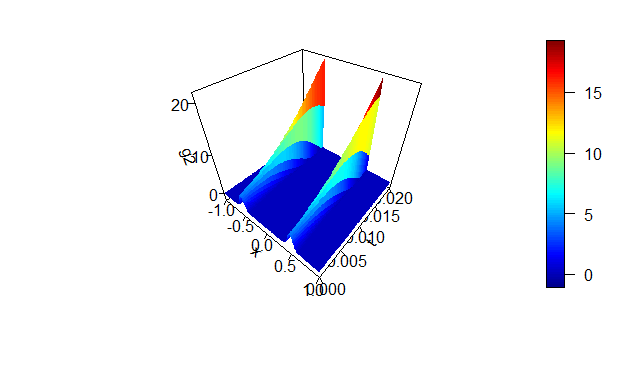

```r
persp3D(sol$x, sol$t, sol$g2,
        xlab="x", ylab="t", zlab="g2",
        ticktype="detailed", nticks=4)
```

```r
plot(sol$x, sol$g2[, 101], type="l", lty="dotted", xlab="x", ylab="")
lines(sol$x, sol$g1[, 101], lty="solid")
```

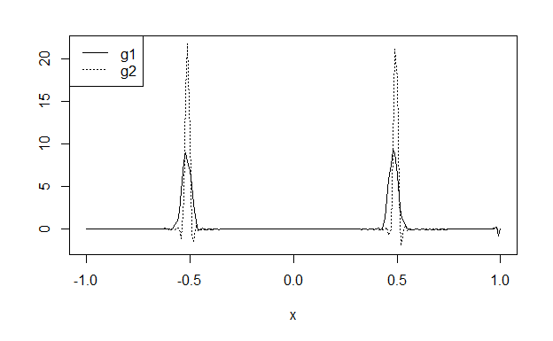

```r
legend("topleft", legend=c("g1", "g2"), lty=c("solid", "dotted"))
```

It is clear that there is scope for improvement in precision but it is a good first shot.

## Numerical Simulations

We present the same numerical examples provided in the original text. We begin by loading the relevant plotting package.

```r
library(plot3Drgl)
```

Note that, due to the instabilities inherent in a forward-difference method, we are required to use small time steps. Due to computational power then, we must constrain ourselves to not reproducing all 1,000 time values as in the original plots. Hence, we seek to reproduce up to $\tau=10$. First, we take the case of symmetric distribution of opinion leaders with $q_i = 0.5, \sigma_i = 0.05, w_i = \pm 0.5$ and interaction radii all set to $r_i = 0.5$. This should be comparable to Figure 3. This initial distribution of opinion leaders is as follows.

```r
seq(-1,1, by = .01) -> x
plot(x,
    g2_w_0(x, qs = c(0.5,0.5), mus = c(0.5, -0.5), sigmas = c(0.05, 0.05)),
    xlab = "Opinion", ylab = "Mass of Leaders", col = 1)
```

[output not shown]

```r
Fig3 <- Opinions(function(x) g1_w_0(x),
                 function(x) g2_w_0(x, qs = c(0.5,0.5), mus = c(0.5, -0.5), sigmas = c(0.05, 0.05)),
                 r1 = 0.5, r2 = 0.5, r3 = 0.5
                 )
```

[output not shown]

```r
persp3D(Fig3$x, Fig3$t, Fig3$g1,
        xlab="w", ylab="t", zlab="g_1",
        ticktype="detailed", nticks=4)
```

[output not shown]

```r
persp3D(Fig3$x, Fig3$t, Fig3$g2,
        xlab="w", ylab="t", zlab="g_2",
        ticktype="detailed", nticks=4)
```

[output not shown]

In case this might be a casualty caused by step sizes in the forward difference method, we make a modification to our forward difference method to reduce the time step’s size if invalid data has occurred and to start from the previous valid time step. We designate this function `OpinionsR`, to stand for a recursive implementation.

```r
OpinionsR <- function(gamma_1_x_0 = function(x) 0*x,
                      gamma_2_x_0 = function(x) 0*x,
                      T = 10, N = 200, Q = max(c(T*100000, 1000)),
                      r1 = 0.5, r2 = 0.5, r3 = 0.5,
                      max_depth = 50, depth = 0
){
  if(depth>max_depth){
    cat("Depth Exceeded, Returning 0.")
    return(0)
  }

  #Define the Grid:
  #Space
  omega = (1-(-1))/N
  x = -1+omega*(0:N)

  #Time
  iota = T/Q
  t = 0+iota*(0:Q)

  #Define Remaining functions
  K1 <- function(w, g1){
    return(K(w,function(v,w) P(v,w,r1), g1, x))
  }

  K2 <- function(w, g2){
    return(K(w,function(v,w) P(v,w,r2), g2, x))
  }

  K3 <- function(w, g2){
    return(K(w,function(v,w) P(v,w,r3), g2, x))
  }

  #Setup Solution Matrices
  gamma_1 = matrix(0, N+1, Q+1)
  gamma_2 = matrix(0, N+1, Q+1)

  #Initial Conditions
  if(depth == 0){
    gamma_1[,1] = gamma_1_x_0(x)
    gamma_2[,1] = gamma_2_x_0(x)
  }else{
    gamma_1[,1] = gamma_1_x_0(1:(N+1))
    gamma_2[,1] = gamma_2_x_0(1:(N+1))
  }

  #Proceed point by point
  for(j in 1:Q){
    gamma_1[1, j+1] = gamma_1[1, j]
    gamma_2[1, j+1] = gamma_2[1, j]
    gamma_1[N+1, j+1] = gamma_1[N+1, j]
    gamma_2[N+1, j+1] = gamma_2[N+1, j]
    for(k in 2:N){
      #Perform the forward difference on the first equation
      aggregate_1 = 0
      aggregate_1 = aggregate_1 +
        1/(tau_1_1*omega)*(
          K1(x[k+1],gamma_1[,j])*gamma_1[k,j]
          +K1(x[k],gamma_1[,j])*gamma_1[k+1,j]
          -2*K1(x[k],gamma_1[,j])*gamma_1[k,j]
        )
      aggregate_1 = aggregate_1 +
        1/(2*tau_1_2*omega)*(
          K3(x[k+1],gamma_1[,j])*gamma_1[k,j]
          +K3(x[k],gamma_1[,j])*gamma_1[k+1,j]
          -2*K3(x[k],gamma_1[,j])*gamma_1[k,j]
        )
      aggregate_1 = aggregate_1 +
        (lambda_1_1*M_1/(2*tau_1_1)+lambda_1_2*M_2/(4*tau_1_2))*((1-x[k]^2)^2)*
        (8*(-1+7*x[k]^2)*gamma_1[k,j]-
           16*x[k]*(1-x[k]^2)*(gamma_1[k+1,j]-gamma_1[k,j])/omega+
           (x[k]^2-1)^2*(gamma_1[k+1,j]-2*gamma_1[k,j]+gamma_1[k-1,j])/(omega^2))
      gamma_1[k,j+1] = gamma_1[k,j]+iota*aggregate_1
      if(is.nan(gamma_1[k,j+1])){
        cat("Encountered NaN at location [1,",k,",", j+1,"]")
        if(j>1){
        Recurse <- OpinionsR(gamma_1_x_0 = function(x) gamma_1[x, j-1],
                             gamma_2_x_0 = function(x) gamma_2[x, j-1],
                             T = 2*iota, N = N, Q = max(c(T*1000, 200)),
                             r1 = r1, r2 = r2, r3 = r3,
                             max_depth = max_depth, depth = depth + 1)
        }
        else{
          Recurse <- OpinionsR(gamma_1_x_0 = function(x) gamma_1[x, j],
                             gamma_2_x_0 = function(x) gamma_2[x, j],
                             T = 2*iota, N = N, Q = max(c(T*1000, 200)),
                             r1 = r1, r2 = r2, r3 = r3,
                             max_depth = max_depth, depth = depth + 1)
        }
        cat(". Returned.\n")
        if(all.equal(Recurse,0)){
          cat("Recursion Strategy Failed. Returning")
          if(depth == 0){
            return(list(x=x, t=t[1:j], g1 = gamma_1[,(1:j)], g2 = gamma_2[,(1:j)]))
          }
          else{
            return(0)
          }
        }
        else{
          gamma_1[k,j+1] = Recurse$g1[,length(Recurse$t)]
          gamma_2[k,j+1] = Recurse$g2[,length(Recurse$t)]
          break
        }
        #return(list(x=x, t=t[1:j], g1 = gamma_1[,(1:j)], g2 = gamma_2[,(1:j)]))
      }
      if(gamma_1[k,j+1]<0){
        cat("Encountered negative at location [1,",k,",",j+1,"]")
        if(j>1){
        Recurse <- OpinionsR(gamma_1_x_0 = function(x) gamma_1[x, j-1],
                             gamma_2_x_0 = function(x) gamma_2[x, j-1],
                             T = 2*iota, N = N, Q = max(c(T*1000, 200)),
                             r1 = r1, r2 = r2, r3 = r3,
                             max_depth = max_depth, depth = depth + 1)
        }
        else{
          Recurse <- OpinionsR(gamma_1_x_0 = function(x) gamma_1[x, j],
                             gamma_2_x_0 = function(x) gamma_2[x, j],
                             T = 2*iota, N = N, Q = max(c(T*1000, 200)),
                             r1 = r1, r2 = r2, r3 = r3,
                             max_depth = max_depth, depth = depth + 1)
        }
        cat(". Returned.\n")
        if(all.equal(Recurse,0)){
          cat("Recursion Strategy Failed. Returning")
          if(depth == 0){
            return(list(x=x, t=t[1:j], g1 = gamma_1[,(1:j)], g2 = gamma_2[,(1:j)]))
          }
          else{
            return(0)
          }
        }
        else{
          gamma_1[k,j+1] = Recurse$g1[,length(Recurse$t)]
          gamma_2[k,j+1] = Recurse$g2[,length(Recurse$t)]
          break
        }
        #return(list(x=x, t=t[1:j], g1 = gamma_1[,(1:j)], g2 = gamma_2[,(1:j)]))
      }

      #Perform the forward difference on the second equation
      aggregate_2 = 0
      aggregate_2 = aggregate_2 +
        1/(tau_2_2*omega)*(
          K2(x[k+1],gamma_2[,j])*gamma_2[k,j]
          +K2(x[k],gamma_2[,j])*gamma_2[k+1,j]
          -2*K2(x[k],gamma_2[,j])*gamma_2[k,j]
        )
      aggregate_2 = aggregate_2 +
        lambda_2_2*M_2/(2*tau_2_2)*((1-x[k]^2)^2)*
        (8*(-1+7*x[k]^2)*gamma_2[k,j]-
           16*x[k]*(1-x[k]^2)*(gamma_2[k+1,j]-gamma_2[k,j])/omega+
           (x[k]^2-1)^2*(gamma_2[k+1,j]-2*gamma_2[k,j]+gamma_2[k-1,j])/(omega^2))
      gamma_2[k,j+1] = gamma_2[k,j]+iota*aggregate_2
      if(is.nan(gamma_2[k,j+1])){
        cat("Encountered NaN at location [2,",k,",", j+1,"]")
        if(j>1){
        Recurse <- OpinionsR(gamma_1_x_0 = function(x) gamma_1[x, j-1],
                             gamma_2_x_0 = function(x) gamma_2[x, j-1],
                             T = 2*iota, N = N, Q = max(c(T*1000, 200)),
                             r1 = r1, r2 = r2, r3 = r3,
                             max_depth = max_depth, depth = depth + 1)
        }
        else{
          Recurse <- OpinionsR(gamma_1_x_0 = function(x) gamma_1[x, j],
                             gamma_2_x_0 = function(x) gamma_2[x, j],
                             T = 2*iota, N = N, Q = max(c(T*1000, 200)),
                             r1 = r1, r2 = r2, r3 = r3,
                             max_depth = max_depth, depth = depth + 1)
        }
        cat(". Returned.\n")
        if(all.equal(Recurse,0)){
          cat("Recursion Strategy Failed. Returning")
          if(depth == 0){
            return(list(x=x, t=t[1:j], g1 = gamma_1[,(1:j)], g2 = gamma_2[,(1:j)]))
          }
          else{
            return(0)
          }
        }
        else{
          gamma_1[k,j+1] = Recurse$g1[,length(Recurse$t)]
          gamma_2[k,j+1] = Recurse$g2[,length(Recurse$t)]
          break
        }
        #return(list(x=x, t=t[1:j], g1 = gamma_1[,(1:j)], g2 = gamma_2[,(1:j)]))
      }
      if(gamma_2[k,j+1]<0){
        cat("Encountered negative at location [2,",k,",",j+1,"]")
        if(j>1){
        Recurse <- OpinionsR(gamma_1_x_0 = function(x) gamma_1[x, j-1],
                             gamma_2_x_0 = function(x) gamma_2[x, j-1],
                             T = 2*iota, N = N, Q = max(c(T*1000, 200)),
                             r1 = r1, r2 = r2, r3 = r3,
                             max_depth = max_depth, depth = depth + 1)
        }
        else{
          Recurse <- OpinionsR(gamma_1_x_0 = function(x) gamma_1[x, j],
                             gamma_2_x_0 = function(x) gamma_2[x, j],
                             T = 2*iota, N = N, Q = max(c(T*1000, 200)),
                             r1 = r1, r2 = r2, r3 = r3,
                             max_depth = max_depth, depth = depth + 1)
        }
        cat(". Returned.\n")
        if(all.equal(Recurse,0)){
          cat("Recursion Strategy Failed. Returning")
          if(depth == 0){
            return(list(x=x, t=t[1:j], g1 = gamma_1[,(1:j)], g2 = gamma_2[,(1:j)]))
          }
          else{
            return(0)
          }
        }
        else{
          gamma_1[k,j+1] = Recurse$g1[,length(Recurse$t)]
          gamma_2[k,j+1] = Recurse$g2[,length(Recurse$t)]
          break
        }
        #return(list(x=x, t=t[1:j], g1 = gamma_1[,(1:j)], g2 = gamma_2[,(1:j)]))
      }
    }
  }
  return(list(x=x, t=t, g1 = gamma_1, g2 = gamma_2))
}
```

This variation, upon detecting a value outside of the correct domain, uses the previous time as a starting point for an even smaller forward-difference method. The hope is that this will avoid any instabilities induced at the current time, and that the finer resolution will allow us to continue.

```r
Fig3R <- OpinionsR(function(x) g1_w_0(x),
                 function(x) g2_w_0(x, qs = c(0.5,0.5), mus = c(0.5, -0.5), sigmas = c(0.05, 0.05)),
                 r1 = 0.5, r2 = 0.5, r3 = 0.5
                 )
```

[output not shown]

```r
persp3D(Fig3R$x, Fig3R$t, Fig3R$g1,
        xlab="w", ylab="t", zlab="g_1",
        ticktype="detailed", nticks=4)
```

[output not shown]

```r
persp3D(Fig3R$x, Fig3R$t, Fig3R$g2,
        xlab="w", ylab="t", zlab="g_2",
        ticktype="detailed", nticks=4)
```

[output not shown]

We now attempt to solve the problem by restricting the results to being non-negative. We first present the most naive method of simply taking $max(0, \gamma_{i,k,j+1})$ as the result for any given step. This is function `OpinionsM`, standing now for maximum.

```r
OpinionsM <- function(gamma_1_x_0 = function(x) 0*x,
                      gamma_2_x_0 = function(x) 0*x,
                      T = 10, N = 200, Q = max(c(T*100000, 1000)),
                      r1 = 0.5, r2 = 0.5, r3 = 0.5
){
  #Define the Grid:
  #Space
  omega = (1-(-1))/N
  x = -1+omega*(0:N)

  #Time
  iota = T/Q
  t = 0+iota*(0:Q)

  #Define Remaining functions
  K1 <- function(w, g1){
    return(K(w,function(v,w) P(v,w,r1), g1, x))
  }

  K2 <- function(w, g2){
    return(K(w,function(v,w) P(v,w,r2), g2, x))
  }

  K3 <- function(w, g2){
    return(K(w,function(v,w) P(v,w,r3), g2, x))
  }

  #Setup Solution Matrices
  gamma_1 = matrix(0, N+1, Q+1)
  gamma_2 = matrix(0, N+1, Q+1)

  #Initial Conditions
  gamma_1[,1] = gamma_1_x_0(x)
  gamma_2[,1] = gamma_2_x_0(x)

  #Proceed point by point
  for(j in 1:Q){
    gamma_1[1, j+1] = gamma_1[1, j]
    gamma_2[1, j+1] = gamma_2[1, j]
    gamma_1[N+1, j+1] = gamma_1[N+1, j]
    gamma_2[N+1, j+1] = gamma_2[N+1, j]
    for(k in 2:N){
      #Perform the forward difference on the first equation
      aggregate_1 = 0
      aggregate_1 = aggregate_1 +
        1/(tau_1_1*omega)*(
          K1(x[k+1],gamma_1[,j])*gamma_1[k,j]
          +K1(x[k],gamma_1[,j])*gamma_1[k+1,j]
          -2*K1(x[k],gamma_1[,j])*gamma_1[k,j]
        )
      aggregate_1 = aggregate_1 +
        1/(2*tau_1_2*omega)*(
          K3(x[k+1],gamma_1[,j])*gamma_1[k,j]
          +K3(x[k],gamma_1[,j])*gamma_1[k+1,j]
          -2*K3(x[k],gamma_1[,j])*gamma_1[k,j]
        )
      aggregate_1 = aggregate_1 +
        (lambda_1_1*M_1/(2*tau_1_1)+lambda_1_2*M_2/(4*tau_1_2))*((1-x[k]^2)^2)*
        (8*(-1+7*x[k]^2)*gamma_1[k,j]-
           16*x[k]*(1-x[k]^2)*(gamma_1[k+1,j]-gamma_1[k,j])/omega+
           (x[k]^2-1)^2*(gamma_1[k+1,j]-2*gamma_1[k,j]+gamma_1[k-1,j])/(omega^2))
      gamma_1[k,j+1] = max(gamma_1[k,j]+iota*aggregate_1,0)
      if(is.nan(gamma_1[k,j+1])){
        cat("Encountered NaN (Fatal) at location [1,",k,",", j+1,"]")
        return(list(x=x, t=t[1:j], g1 = gamma_1[,(1:j)], g2 = gamma_2[,(1:j)]))
      }
      if(is.infinite(gamma_1[k,j+1])){
        cat("Encountered Inf (Fatal) at location [1,",k,",", j+1,"]")
        return(list(x=x, t=t[1:j], g1 = gamma_1[,(1:j)], g2 = gamma_2[,(1:j)]))
      }

      #Perform the forward difference on the second equation
      aggregate_2 = 0
      aggregate_2 = aggregate_2 +
        1/(tau_2_2*omega)*(
          K2(x[k+1],gamma_2[,j])*gamma_2[k,j]
          +K2(x[k],gamma_2[,j])*gamma_2[k+1,j]
          -2*K2(x[k],gamma_2[,j])*gamma_2[k,j]
        )
      aggregate_2 = aggregate_2 +
        lambda_2_2*M_2/(2*tau_2_2)*((1-x[k]^2)^2)*
        (8*(-1+7*x[k]^2)*gamma_2[k,j]-
           16*x[k]*(1-x[k]^2)*(gamma_2[k+1,j]-gamma_2[k,j])/omega+
           (x[k]^2-1)^2*(gamma_2[k+1,j]-2*gamma_2[k,j]+gamma_2[k-1,j])/(omega^2))
      gamma_2[k,j+1] = max(gamma_2[k,j]+iota*aggregate_2,0)
      if(is.nan(gamma_2[k,j+1])){
        cat("Encountered NaN (Fatal) at location [2,",k,",", j+1,"]")
        return(list(x=x, t=t[1:j], g1 = gamma_1[,(1:j)], g2 = gamma_2[,(1:j)]))
      }
      if(is.infinite(gamma_2[k,j+1])){
        cat("Encountered Inf (Fatal) at location [2,",k,",", j+1,"]")
        return(list(x=x, t=t[1:j], g1 = gamma_1[,(1:j)], g2 = gamma_2[,(1:j)]))
      }
    }
  }
  return(list(x=x, t=t, g1 = gamma_1, g2 = gamma_2))
}
```

```r
Fig3M <- OpinionsM(function(x) g1_w_0(x),
                   function(x) g2_w_0(x, qs = c(0.5,0.5), mus = c(0.5, -0.5), sigmas = c(0.05, 0.05)),
                   r1 = 0.5, r2 = 0.5, r3 = 0.5
)
```

```r
persp3D(Fig3M$x, Fig3M$t, Fig3M$g1,
        xlab="w", ylab="t", zlab="g_1",
        ticktype="detailed", nticks=4)
```

[output not shown]

```r
persp3D(Fig3M$x, Fig3M$t, Fig3M$g2,
        xlab="w", ylab="t", zlab="g_2",
        ticktype="detailed", nticks=4)
```

[output not shown]

Unfortunately, this reveals an instability. We suspect that this instability is due to a lack of conservation of the mass. As such, are next attempt is to solve the problem via a very naive attempt at smoothing, i.e. shifting mass from the nearest neighbors on the left and right to fill in prospective negative values. We arrive at `OpinionsZ`, for zero-handling.

```r
OpinionsZ <- function(gamma_1_x_0 = function(x) 0*x,
                      gamma_2_x_0 = function(x) 0*x,
                      T = 10, N = 200, Q = max(c(T*100000, 1000)),
                      r1 = 0.5, r2 = 0.5, r3 = 0.5
){
  #Define the Grid:
  #Space
  omega = (1-(-1))/N
  x = -1+omega*(0:N)

  #Time
  iota = T/Q
  t = 0+iota*(0:Q)

  #Define Remaining functions
  K1 <- function(w, g1){
    return(K(w,function(v,w) P(v,w,r1), g1, x))
  }

  K2 <- function(w, g2){
    return(K(w,function(v,w) P(v,w,r2), g2, x))
  }

  K3 <- function(w, g2){
    return(K(w,function(v,w) P(v,w,r3), g2, x))
  }

  #Setup Solution Matrices
  gamma_1 = matrix(0, N+1, Q+1)
  gamma_2 = matrix(0, N+1, Q+1)

  #Initial Conditions
  gamma_1[,1] = gamma_1_x_0(x)
  gamma_2[,1] = gamma_2_x_0(x)

  #Proceed point by point
  for(j in 1:Q){
    gamma_1[1, j+1] = gamma_1[1, j]
    gamma_2[1, j+1] = gamma_2[1, j]
    gamma_1[N+1, j+1] = gamma_1[N+1, j]
    gamma_2[N+1, j+1] = gamma_2[N+1, j]
    Zeros_1 = c()
    Zeros_2 = c()
    for(k in 2:N){
      #Perform the forward difference on the first equation
      aggregate_1 = 0
      aggregate_1 = aggregate_1 +
        1/(tau_1_1*omega)*(
          K1(x[k+1],gamma_1[,j])*gamma_1[k,j]
          +K1(x[k],gamma_1[,j])*gamma_1[k+1,j]
          -2*K1(x[k],gamma_1[,j])*gamma_1[k,j]
        )
      aggregate_1 = aggregate_1 +
        1/(2*tau_1_2*omega)*(
          K3(x[k+1],gamma_1[,j])*gamma_1[k,j]
          +K3(x[k],gamma_1[,j])*gamma_1[k+1,j]
          -2*K3(x[k],gamma_1[,j])*gamma_1[k,j]
        )
      aggregate_1 = aggregate_1 +
        (lambda_1_1*M_1/(2*tau_1_1)+lambda_1_2*M_2/(4*tau_1_2))*((1-x[k]^2)^2)*
        (8*(-1+7*x[k]^2)*gamma_1[k,j]-
           16*x[k]*(1-x[k]^2)*(gamma_1[k+1,j]-gamma_1[k,j])/omega+
           (x[k]^2-1)^2*(gamma_1[k+1,j]-2*gamma_1[k,j]+gamma_1[k-1,j])/(omega^2))
      gamma_1[k,j+1] = gamma_1[k,j]+iota*aggregate_1
      if(is.nan(gamma_1[k,j+1])){
        cat("Encountered NaN (Fatal) at location [1,",k,",", j+1,"]")
        return(list(x=x, t=t[1:j], g1 = gamma_1[,(1:j)], g2 = gamma_2[,(1:j)]))
      }
      if(is.infinite(gamma_1[k,j+1])){
        cat("Encountered Inf (Fatal) at location [1,",k,",", j+1,"]")
        return(list(x=x, t=t[1:j], g1 = gamma_1[,(1:j)], g2 = gamma_2[,(1:j)]))
      }
      if(gamma_1[k,j+1]<0){
        Zeros_1 = c(Zeros_1,k)
        #return(list(x=x, t=t[1:j], g1 = gamma_1[,(1:j)], g2 = gamma_2[,(1:j)]))
      }

      #Perform the forward difference on the second equation
      aggregate_2 = 0
      aggregate_2 = aggregate_2 +
        1/(tau_2_2*omega)*(
          K2(x[k+1],gamma_2[,j])*gamma_2[k,j]
          +K2(x[k],gamma_2[,j])*gamma_2[k+1,j]
          -2*K2(x[k],gamma_2[,j])*gamma_2[k,j]
        )
      aggregate_2 = aggregate_2 +
        lambda_2_2*M_2/(2*tau_2_2)*((1-x[k]^2)^2)*
        (8*(-1+7*x[k]^2)*gamma_2[k,j]-
           16*x[k]*(1-x[k]^2)*(gamma_2[k+1,j]-gamma_2[k,j])/omega+
           (x[k]^2-1)^2*(gamma_2[k+1,j]-2*gamma_2[k,j]+gamma_2[k-1,j])/(omega^2))
      gamma_2[k,j+1] = gamma_2[k,j]+iota*aggregate_2
      if(is.nan(gamma_2[k,j+1])){
        cat("Encountered NaN (Fatal) at location [2,",k,",", j+1,"]")
        return(list(x=x, t=t[1:j], g1 = gamma_1[,(1:j)], g2 = gamma_2[,(1:j)]))
      }
      if(is.infinite(gamma_2[k,j+1])){
        cat("Encountered Inf (Fatal) at location [2,",k,",", j+1,"]")
        return(list(x=x, t=t[1:j], g1 = gamma_1[,(1:j)], g2 = gamma_2[,(1:j)]))
      }
      if(gamma_2[k,j+1]<0){
        Zeros_2 = c(Zeros_2,k)
        #return(list(x=x, t=t[1:j], g1 = gamma_1[,(1:j)], g2 = gamma_2[,(1:j)]))
      }
    }

    #Perform Smoothing to "fill" the negative regions to zero.
    #Idea is to take from neighbors what was illegally taken from this position,
    #but we must not turn neighbors into illegal values either.
    if(length(Zeros_1)){
      for(i in 1:length(Zeros_1)){
        Amount_To_Fill = -gamma_1[Zeros_1[i], j+1]
        Neighbor_L = Zeros_1[i]-1
        Neighbor_R = Zeros_1[i]+1
        while(Neighbor_L>0 &
              (gamma_1[Neighbor_L,j+1]<=0)){
          Neighbor_L = Neighbor_L - 1
        }
        while(Neighbor_R<(N+2) &
              (gamma_1[Neighbor_R,j+1]<=0)){
          Neighbor_R = Neighbor_R + 1
        }
        Neighbor_L_has = 0
        if(Neighbor_L>0){
          Neighbor_L_has = gamma_1[Neighbor_L, j+1]
        }
        Neighbor_R_has = 0
        if(Neighbor_R<(N+2)){
          Neighbor_R_has = gamma_1[Neighbor_R, j+1]
        }
        while(Neighbor_L_has+Neighbor_R_has<Amount_To_Fill){
          flag = 0
          if(Neighbor_L>1){
            if(Neighbor_L_has < gamma_1[Neighbor_L-1, j+1]){
              Neighbor_L = Neighbor_L-1
              Neighbor_L_has = gamma_1[Neighbor_L, j+1]
            }else{flag = flag + 1}
            }else{flag = flag + 1}
          if(Neighbor_R<(N+1)){
            if(Neighbor_R_has < gamma_1[Neighbor_R+1, j+1]){
              Neighbor_R = Neighbor_R+1
              Neighbor_R_has = gamma_1[Neighbor_R, j+1]

            }else{flag = flag + 1}
            }else{flag = flag + 1}
          if(flag==2){
            cat("Smoothing Strategy failed. Returning.")
            return(list(x=x, t=t[1:j], g1 = gamma_1[,(1:j)], g2 = gamma_2[,(1:j)]))
          }
        }
        Amount_Remain = Neighbor_L_has + Neighbor_R_has - Amount_To_Fill
        if(Neighbor_L>0){
          gamma_1[Neighbor_L, k+1] = Amount_Remain * Neighbor_L_has/(Neighbor_L_has+Neighbor_R_has)}
        if(Neighbor_R<(N+2)){
          gamma_1[Neighbor_R, k+1] = Amount_Remain * Neighbor_R_has/(Neighbor_L_has+Neighbor_R_has)}
        gamma_1[Zeros_1[i], k+1] = 0
      }
    }

    if(length(Zeros_2)){
      for(i in 1:length(Zeros_2)){
        Amount_To_Fill = -gamma_2[Zeros_2[i], j+1]
        Neighbor_L = Zeros_2[i]-1
        Neighbor_R = Zeros_2[i]+1
        while(Neighbor_L>0 &
              (gamma_2[Neighbor_L,j+1]<0)){
          Neighbor_L = Neighbor_L - 1
        }
        while(Neighbor_R<(N+2) &
              (gamma_2[Neighbor_R,j+1]<0)){
          Neighbor_R = Neighbor_R + 1
        }
        Neighbor_L_has = 0
        if(Neighbor_L>0){
          Neighbor_L_has = gamma_2[Neighbor_L, j+1]
        }
        Neighbor_R_has = 0
        if(Neighbor_R<(N+2)){
          Neighbor_R_has = gamma_2[Neighbor_R, j+1]
        }
        while(Neighbor_L_has+Neighbor_R_has<Amount_To_Fill){
          flag = 0
          if(Neighbor_L>1){
            if(Neighbor_L_has < gamma_2[Neighbor_L-1, j+1]){
              Neighbor_L = Neighbor_L-1
              Neighbor_L_has = gamma_2[Neighbor_L, j+1]
            }else{flag = flag + 1}
            }else{flag = flag + 1}
          if(Neighbor_R<(N+1)){
            if(Neighbor_R_has < gamma_2[Neighbor_R+1, j+1]){
              Neighbor_R = Neighbor_R+1
              Neighbor_R_has = gamma_2[Neighbor_R, j+1]

            }else{flag = flag + 1}
            }else{flag = flag + 1}
          if(flag==2){
            cat("Smoothing Strategy failed. Returning.")
            return(list(x=x, t=t[1:j], g1 = gamma_1[,(1:j)], g2 = gamma_2[,(1:j)]))
          }
        }
        Amount_Remain = Neighbor_L_has + Neighbor_R_has - Amount_To_Fill
        if(Neighbor_L>0){
          gamma_2[Neighbor_L, k+1] = Amount_Remain * Neighbor_L_has/(Neighbor_L_has+Neighbor_R_has)}
        if(Neighbor_R<(N+2)){
          gamma_2[Neighbor_R, k+1] = Amount_Remain * Neighbor_R_has/(Neighbor_L_has+Neighbor_R_has)}
        gamma_2[Zeros_2[i], k+1] = 0
      }
    }
  }
  return(list(x=x, t=t, g1 = gamma_1, g2 = gamma_2))
}
```

```r
Fig3Z <- OpinionsZ(function(x) g1_w_0(x),
                   function(x) g2_w_0(x, qs = c(0.5,0.5), mus = c(0.5, -0.5), sigmas = c(0.05, 0.05)),
                   r1 = 0.5, r2 = 0.5, r3 = 0.5
)
```

```r
persp3D(Fig3Z$x, Fig3Z$t, Fig3Z$g1,
        xlab="w", ylab="t", zlab="g_1",
        ticktype="detailed", nticks=4)
```

[output not shown]

```r
persp3D(Fig3Z$x, Fig3Z$t, Fig3Z$g2,
        xlab="w", ylab="t", zlab="g_2",
        ticktype="detailed", nticks=4)
```

[output not shown]

Unfortunately, conserving the mass does not appear to have resolved our instability and has reduced the amount of time for which we can continue our method.

Taking inspiration now from the Lax scheme, we attempt to increase the stability of our approach by exchanging forward difference steps for averaged central differences. We modify the following constituent parts.

$$\begin{align}
\partial_{w}(\frac{1}{\tau_{2,2}} \mathcal{K}_2 (w,\tau) g_2(w,t)) &= \frac{1}{\tau_{2,2}}\partial_{w}( \mathcal{K}_2 (w,\tau) g_2(w,t))\\
&=\frac{1}{\tau_{2,2}}( \partial_{w}(\mathcal{K}_2 (w,\tau)) g_2(w,t))+\mathcal{K}_2 (w,\tau) \partial_{w}(g_2(w,t)))\\
&\implies \frac{1}{\tau_{2,2}}( \frac{\mathcal{K}_2(x_k+\omega,t_j)-\mathcal{K}_2(x_k-\omega,t_j)}{2\omega}\gamma_{2,k,j} + \mathcal{K}_2(x_k,t_j)\frac{\gamma_{2,k+1,j}-\gamma_{2,k-1,j}}{2\omega})
\end{align}$$

$$\begin{align}
\partial_{w}((\frac{1}{\tau_{1,1}} \mathcal{K}_1 (w,\tau) + \frac{1}{2 \tau_{1,2}} \mathcal{K}_3(w,\tau))g_1(w,t))
&=
\partial_{w}(\frac{1}{\tau_{1,1}} \mathcal{K}_1 (w,\tau)g_1(w,t)) + \partial_{w}(\frac{1}{2 \tau_{1,2}} \mathcal{K}_3(w,\tau)g_1(w,t)) \\
\implies& \frac{1}{2\omega \tau_{1,1}}( \mathcal{K}_1(x_k+\omega,t_j)\gamma_{1,k,j}-\mathcal{K}_1(x_k-\omega,t_j)\gamma_{1,k,j}+ \mathcal{K}_1(x_k,t_j)\gamma_{1,k+1,j} - \mathcal{K}_1(x_k,t_j)\gamma_{1,k-1,j}) \\
&+ \frac{1}{4 \omega \tau_{1,2}}( \mathcal{K}_3(x_k+\omega,t_j)\gamma_{1,k,j}-\mathcal{K}_3(x_k-\omega,t_j)\gamma_{1,k,j}+ \mathcal{K}_3(x_k,t_j)\gamma_{1,k+1,j} - \mathcal{K}_3(x_k,t_j)\gamma_{1,k-1,j})
\end{align}$$

These three changes, along with using the previous time step with its average in the forward-difference formula for the time derivative, yield the following system.

$$\begin{align}
\text{for } k = 1,\ldots, N-1\\
\gamma_{1,k,j+1}&=\frac{1}{2}(\gamma_{1,k+1,j}+\gamma_{1,k-1,j})\\
&+\iota(\frac{1}{2\omega \tau_{1,1}}( \mathcal{K}_1(x_k+\omega,t_j)\gamma_{1,k,j}-\mathcal{K}_1(x_k-\omega,t_j)\gamma_{1,k,j}+ \mathcal{K}_1(x_k,t_j)\gamma_{1,k+1,j} - \mathcal{K}_1(x_k,t_j)\gamma_{1,k-1,j}) \\
&+ \frac{1}{4 \omega \tau_{1,2}}( \mathcal{K}_3(x_k+\omega,t_j)\gamma_{1,k,j}-\mathcal{K}_3(x_k-\omega,t_j)\gamma_{1,k,j}+ \mathcal{K}_3(x_k,t_j)\gamma_{1,k+1,j} - \mathcal{K}_3(x_k,t_j)\gamma_{1,k-1,j})\\
&+(\frac{\lambda_{1,1} M_1}{2 \tau_{1,1}} + \frac{\lambda_{1,2} M_2}{4 \tau_{1,2}})
(1-x_k^2)^2 (4(-1+7x_k^2) (\gamma_{1,k+1,j} + \gamma_{1,k-1,j}) - 8x_k(1-x_k^2)\frac{\gamma_{1,k+1,j}-\gamma_{1,k-1,j}}{\omega}+(1-x_k^2)^2\frac{\gamma_{1,k+1,j}-2\gamma_{1,k,j}+\gamma_{1,k-1,j}}{\omega^2}))
) \\
\\
\gamma_{2,k,j+1}&=\frac{1}{2}(\gamma_{2,k+1,j}+\gamma_{2,k-1,j})\\
&+\iota(\frac{1}{2\omega\tau_{2,2}}( (\mathcal{K}_2(x_k+\omega,t_j)-\mathcal{K}_2(x_k-\omega,t_j))\gamma_{2,k,j} + \mathcal{K}_2(x_k,t_j)(\gamma_{2,k+1,j}-\gamma_{2,k-1,j})\\
&+\frac{\lambda_{2,2} M_2}{2 \tau_{2,2}}
(1-x_k^2)^2 (4(-1+7x_k^2) (\gamma_{2,k+1,j}+\gamma_{2,k-1,j}) - 8x_k(1-x_k^2)\frac{\gamma_{2,k+1,j}-\gamma_{2,k-1,j}}{\omega}+(1-x_k^2)^2\frac{\gamma_{2,k+1,j}-2\gamma_{2,k,j}+\gamma_{2,k-1,j}}{\omega^2}))
) \\
\\
\text{for } k = 0 \text{ or } k = N\\
\implies x_k = \pm 1\\
\gamma_{1,k,j+1} &= \gamma_{1,k,j}\\
\gamma_{2,k,j+1} &= \gamma_{2,k,j}
\end{align}$$

The implementation of these changes leads to `OpinionsC`, standing now for central.

```r
OpinionsC <- function(gamma_1_x_0 = function(x) 0*x,
                     gamma_2_x_0 = function(x) 0*x,
                     T = 10, N = 200, Q = T*100000,
                     r1 = 0.5, r2 = 0.5, r3 = 0.5
                     ){
  #Define the Grid:
  #Space
  omega = (1-(-1))/N
  x = -1+omega*(0:N)

  #Time
  iota = T/Q
  t = 0+iota*(0:Q)

  #Define Remaining functions
  K1 <- function(w, g1){
    return(K(w,function(v,w) P(v,w,r1), g1, x))
  }

  K2 <- function(w, g2){
    return(K(w,function(v,w) P(v,w,r2), g2, x))
  }

  K3 <- function(w, g2){
    return(K(w,function(v,w) P(v,w,r3), g2, x))
  }

  #Setup Solution Matrices
  gamma_1 = matrix(0, N+1, Q+1)
  gamma_2 = matrix(0, N+1, Q+1)

  #Initial Conditions
  gamma_1[,1] = gamma_1_x_0(x)
  gamma_2[,1] = gamma_2_x_0(x)

  #Proceed point by point
  for(j in 1:Q){
    gamma_1[1, j+1] = gamma_1[1, j]
    gamma_2[1, j+1] = gamma_2[1, j]
    for(k in 2:N){
      #Perform the forward difference on the first equation
      aggregate_1 = 0
      aggregate_1 = aggregate_1 +
                    1/(2*tau_1_1*omega)*(
                    K1(x[k+1],gamma_1[,j])*gamma_1[k,j]
                    -K1(x[k-1],gamma_1[,j])*gamma_1[k,j]
                    +K1(x[k],gamma_1[,j])*gamma_1[k+1,j]
                    -K1(x[k],gamma_1[,j])*gamma_1[k-1,j]
                    )
      aggregate_1 = aggregate_1 +
                    1/(4*tau_1_2*omega)*(
                    K3(x[k+1],gamma_1[,j])*gamma_1[k,j]
                    -K3(x[k-1],gamma_1[,j])*gamma_1[k,j]
                    +K3(x[k],gamma_1[,j])*gamma_1[k+1,j]
                    -K3(x[k],gamma_1[,j])*gamma_1[k-1,j]
                    )
      aggregate_1 = aggregate_1 +
                    (lambda_1_1*M_1/(2*tau_1_1)+lambda_1_2*M_2/(4*tau_1_2))*((1-x[k]^2)^2)*
                    (4*(-1+7*x[k]^2)*(gamma_1[k+1,j]+gamma_1[k-1,j])-
                    8*x[k]*(1-x[k]^2)*(gamma_1[k+1,j]-gamma_1[k-1,j])/omega+
                    (x[k]^2-1)^2*(gamma_1[k+1,j]-2*gamma_1[k,j]+gamma_1[k-1,j])/(omega^2))
      gamma_1[k,j+1] = .5*(gamma_1[k+1,j]+gamma_1[k-1,j])+iota*aggregate_1
      if(is.nan(gamma_1[k,j+1])){
        cat("Encountered NaN at location [1,",k,",", j+1,"]")
        return(list(x=x, t=t[1:j], g1 = gamma_1[,(1:j)], g2 = gamma_2[,(1:j)]))
      }
      if(gamma_1[k,j+1]<0){
        cat("Encountered negative at location [1,",k,",",j+1,"]")
        return(list(x=x, t=t[1:j], g1 = gamma_1[,(1:j)], g2 = gamma_2[,(1:j)]))
      }

      #Perform the forward difference on the second equation
      aggregate_2 = 0
      aggregate_2 = aggregate_2 +
                    1/(2*tau_2_2*omega)*(
                    K2(x[k+1],gamma_2[,j])*gamma_2[k,j]
                    -K2(x[k-1],gamma_2[,j])*gamma_2[k,j]
                    +K2(x[k],gamma_2[,j])*gamma_2[k+1,j]
                    -K2(x[k],gamma_2[,j])*gamma_2[k-1,j]
                    )
      aggregate_2 = aggregate_2 +
                    lambda_2_2*M_2/(2*tau_2_2)*((1-x[k]^2)^2)*
                    (4*(-1+7*x[k]^2)*(gamma_2[k+1,j]+gamma_2[k-1,j])-
                    8*x[k]*(1-x[k]^2)*(gamma_2[k+1,j]-gamma_2[k-1,j])/omega+
                    (x[k]^2-1)^2*(gamma_2[k+1,j]-2*gamma_2[k,j]+gamma_2[k-1,j])/(omega^2))
      gamma_2[k,j+1] = .5*(gamma_2[k+1,j]+gamma_2[k-1,j])+iota*aggregate_2
      if(is.nan(gamma_2[k,j+1])){
        cat("Encountered NaN at location [2,",k,",", j+1,"]")
        return(list(x=x, t=t[1:j], g1 = gamma_1[,(1:j)], g2 = gamma_2[,(1:j)]))
      }
      if(gamma_2[k,j+1]<0){
        cat("Encountered negative at location [2,",k,",",j+1,"]")
        return(list(x=x, t=t[1:j], g1 = gamma_1[,(1:j)], g2 = gamma_2[,(1:j)]))
      }
    }
    gamma_1[N+1, j+1] = gamma_1[N+1, j]
    gamma_2[N+1, j+1] = gamma_2[N+1, j]
  }
  return(list(x=x, t=t, g1 = gamma_1, g2 = gamma_2))
}
```

```r
Fig3C <- OpinionsC(function(x) g1_w_0(x),
                 function(x) g2_w_0(x, qs = c(0.5,0.5), mus = c(0.5, -0.5), sigmas = c(0.05, 0.05)),
                 r1 = 0.5, r2 = 0.5, r3 = 0.5
                 )
```

```r
persp3D(Fig3C$x, Fig3C$t, Fig3C$g1,
        xlab="w", ylab="t", zlab="g_1",
        ticktype="detailed", nticks=4)
```

[output not shown]

```r
persp3D(Fig3C$x, Fig3C$t, Fig3C$g2,
        xlab="w", ylab="t", zlab="g_2",
        ticktype="detailed", nticks=4)
```

[output not shown]

This demonstrates that while we have gained stability, we appear to not have convergence to the expected solution! We also cannot conclude whether the lack of convergence to the expected solution is an innate quality of the methods we have tried thus far, or merely due to the use of central difference formulas. As such, we cannot at this stage conclude that are treatment is faulty.

Finally, we attempt to utilize the method of lines to solve our system. This will reduce our system to a system of ordinary differential equations with derivatives only with respect to $\tau$. Then a standard ordinary differential equation solver can be used to progress the system, as noted in lab 12. We first load an appropriate `ode` function using the library `deSolve`.

```r
library(deSolve)
```

Recalling our forward difference scheme with the time derivative unevaluated, we have the following system.

We implement this system in the method of lines function `OpinionsL`, using the required syntax for our solver and recycling from our previous implementations as appropriate.

```r
OpinionsL <-function(gamma_1_x_0 = function(x) 0*x,
                     gamma_2_x_0 = function(x) 0*x,
                     T = 10, N = 200, Q = T*100000,
                     r1 = 0.5, r2 = 0.5, r3 = 0.5
                     )
{
  #Define the Grid:
  #Space
  omega = (1-(-1))/N
  x = -1+omega*(0:N)

  #Time
  iota = T/Q
  t = 0+iota*(0:Q)

  #Define Remaining functions
  K1 <- function(w, g1){
    return(K(w,function(v,w) P(v,w,r1), g1, x))
  }

  K2 <- function(w, g2){
    return(K(w,function(v,w) P(v,w,r2), g2, x))
  }

  K3 <- function(w, g2){
    return(K(w,function(v,w) P(v,w,r3), g2, x))
  }

  #Function that computes the time derivatives
  #of the two distributions
  #at each point in the space.
  #Assume y values are c(gamma_1, gamma_2)
  system <- function(t, y, parms){
    #Retrieve inputs
    gamma_1 = y[1:(N+1)]
    gamma_2 = y[(N+1+1):(2*(N+1))]

    #solution storage
    dgamma_1dt = rep(0, N+1)
    dgamma_2dt = rep(0, N+1)

    #Recycling code
    for(k in 2:N){
      #Perform the forward difference on the first equation
      aggregate_1 = 0
      aggregate_1 = aggregate_1 +
                    1/(2*tau_1_1*omega)*(
                    K1(x[k+1],gamma_1[])*gamma_1[k]
                    -K1(x[k-1],gamma_1[])*gamma_1[k]
                    +K1(x[k],gamma_1[])*gamma_1[k+1]
                    -K1(x[k],gamma_1[])*gamma_1[k-1]
                    )
      aggregate_1 = aggregate_1 +
                    1/(4*tau_1_2*omega)*(
                    K3(x[k+1],gamma_1[])*gamma_1[k]
                    -K3(x[k-1],gamma_1[])*gamma_1[k]
                    +K3(x[k],gamma_1[])*gamma_1[k+1]
                    -K3(x[k],gamma_1[])*gamma_1[k-1]
                    )
      aggregate_1 = aggregate_1 +
                    (lambda_1_1*M_1/(2*tau_1_1)+lambda_1_2*M_2/(4*tau_1_2))*((1-x[k]^2)^2)*
                    (8*(-1+7*x[k]^2)*gamma_1[k]-
                    8*x[k]*(1-x[k]^2)*(gamma_1[k+1]-gamma_1[k-1])/omega+
                    (x[k]^2-1)^2*(gamma_1[k+1]-2*gamma_1[k]+gamma_1[k-1])/(omega^2))
      dgamma_1dt[k]=aggregate_1

      #Perform the forward difference on the second equation
      aggregate_2 = 0
      aggregate_2 = aggregate_2 +
                    1/(2*tau_2_2*omega)*(
                    K2(x[k+1],gamma_2[])*gamma_2[k]
                    -K2(x[k-1],gamma_2[])*gamma_2[k]
                    +K2(x[k],gamma_2[])*gamma_2[k+1]
                    -K2(x[k],gamma_2[])*gamma_2[k-1]
                    )
      aggregate_2 = aggregate_2 +
                    lambda_2_2*M_2/(2*tau_2_2)*((1-x[k]^2)^2)*
                    (8*(-1+7*x[k]^2)*gamma_2[k]-
                    8*x[k]*(1-x[k]^2)*(gamma_2[k+1]-gamma_2[k-1])/omega+
                    (x[k]^2-1)^2*(gamma_2[k+1]-2*gamma_2[k]+gamma_2[k-1])/(omega^2))
      dgamma_2dt[k] = aggregate_2
    }

    return(list(c(dgamma_1dt,dgamma_2dt)))
  }

  soln <- ode(c(gamma_1_x_0(x),gamma_2_x_0(x)),t,system, parms = NULL)
  P <- t(soln[, 2:(N+2)])
  Z <- t(soln[, (N+3):(2*N+3)])
  return(list(x=x, t=t, g1=P, g2=Z, soln=soln))
}
```

```r
Fig3L <- OpinionsL(function(x) g1_w_0(x),
                 function(x) g2_w_0(x, qs = c(0.5,0.5), mus = c(0.5, -0.5), sigmas = c(0.05, 0.05)),
                 r1 = 0.5, r2 = 0.5, r3 = 0.5
                 )
```

After approximately 14 hours of work we received the following warning message. Warning messages: 1: In lsoda(y, times, func, parms, …) : an excessive amount of work (> maxsteps ) was done, but integration was not successful - increase maxsteps 2: In lsoda(y, times, func, parms, …) : Returning early. Results are accurate, as far as they go

```r
persp3D(Fig3L$x, Fig3L$t[seq(from = 1, to = length(Fig3L$t), by = 20)], Fig3L$g1[,seq(from = 1, to = length(Fig3L$t), by = 20)],
        xlab="w", ylab="t", zlab="g_1",
        ticktype="detailed", nticks=4)
```

[output not shown]

```r
persp3D(Fig3L$x, Fig3L$t[seq(from = 1, to = length(Fig3L$t), by = 20)], Fig3L$g2[,seq(from = 1, to = length(Fig3L$t), by = 20)],
        xlab="w", ylab="t", zlab="g_2",
        ticktype="detailed", nticks=4)
```

[output not shown]

On the one hand, this is the furthest number of time steps reached. On the other, we still have an instability, which we can now suspect is inherent to the simple forward-difference method when applied to this system, as well as a method that is very taxing for computers. Reusing the data somewhat, we look to see what is happening until $t = 1.5$.

```r
persp3D(Fig3L$x, Fig3L$t[seq(from = 1, to = 150001, by = 20)], Fig3L$g2[,seq(from = 1, to = 150001, by = 20)],
        xlab="w", ylab="t", zlab="g_2",
        ticktype="detailed", nticks=4)
```

[output not shown]